# Lesson 5: Model assumptions

Last updated in March 2021

## Goals for today

- Learn about assumptions of linear regression
- Learn how to use diagnostic plots
- Learn about the limitations of statistical test for assumption checking

## Bias and random error

- Total error composed of two parts: bias and random error
- Bias - systemic error, i.e. systemic under- or overestimation of the expected values
- Random error - random deviations from the true value (due to the sampling and measurement error)
- Violations of assumption can increase either or both

## Precision and efficiency

- Precision
  - reciprocal to the random error (high precision = low random error)
- Efficiency
  - how many observations we need to achieve a specific level of performance
  - e.g. model based on data that meet its assumptions require less observations to achieve 80% statistical power, i.e. is more efficient

## How to think about assumptions

- Regression models represent a simplification of real world
- To make this simplification, some assumptions have to be made
- All models make assumptions
- It is important to realize that no real model actually meet all assumptions we make (in fact, most models don’t meet any of our assumptions exactly)
- Models can be by useful even when assumptions are wrong
- What is important is to what extent are our assumptions violated

## How to think about assumptions

- Don’t think about assumptions in binary term (*“ok”* vs *“bad”*)
- Instead, think *how much* we deviate from them
- Not all assumption are also important for all tasks
- Therefore, we need to know why are some assumptions important and what happens when they are wrong

## Assumptions of linear regression

- Helpfully sorted by Gelman et al. (2020) in order of (general) importance:
  - Validity
  - Representativeness
  - Linearity and additivity
  - Independence of errors
  - Homoscedasticity of errors
  - Normality of errors

## Validity

- Most important and at the same time most elusive assumption
- Relates to both our data and our model
- Firstly, we should make sure that the data we use are sufficient to answer the research question at hand (e.g. no important variable is missing)
  - Often a problem in secondary analysis
- Secondly, all traits and phenomena we want to analyze need to be measured with sufficient quality
  - Remember to checks instrument’s quality and don’t mistake related traits for each other

## Validity

- Thirdly, data must be gathered in such way that inference to the desired population is possible
- Lastly, our models has to be correctly specified to capture the true relationships between variables.
- Violation of this assumption will lead to bias

## Representativeness

- If our goal is either prediction or inference, our data needs to be a representative sample of the population of interest
- More specifically, we assume that the distribution of the dependent variable is representative of the population, given the the predictors

## Representativeness

- If our goal is only to describe relationship between variables, and we aren’t interested in measures of centrality, we don’t actually need our sample to be representative in all aspects
- Consider model predicting `income` based on `age`. What happens if our data are not representative?
  - More specifically, what if only people with above average age/income participate in our survey?

## Representativeness

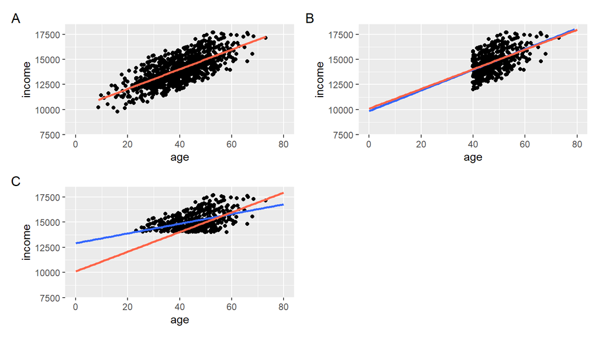

- We get unbiased estimate of the regression coefficient even when sample is not representative in terms of age (independent variable)

## Linearity and additivity

- Linear models are linear, because they assume linear form:

\[ y = \beta_0 + \beta_1*x_1 + \beta_2*x_2\:+\:...\:\beta_p*x_p \]

- No all relationship are neccesary linear though:

\[ y = \beta_0 + (\beta_1*x_1) * (\beta_2*x_2) \] - Model is linear, if the regression coefficients are only either add or subtracted from each other

## Linearity and additivity

- Some nonlinear models can be translated into linear form using an appropriate transformation:

\[ \beta_0 + log[(\beta_1*x_1) * (\beta_2*x_2)] = \beta_0 + log(\beta_1*x_1) + log(\beta_2*x_2) \]

- Linear models can only capture relationships that fulfill this assumption
- Violation of this assumption leads to bias

## Independence of errors

- Linear regression assumes that differences between the true and the predicted values, are independent of each other across the range of the predictors.
- Often violated in time series, where the errors at the time of t are correlated with the errors at the time of t-1 (or t-2, t-3, etc.).
- Also problem in spatial analysis
- Violation of this assumption leads to incorrect estimation of standard error, and therefore presents a risk to inference

## Homoscedasticity (constant variance of errors)

- The standard linear regression is derived under the assumption that the errors have the same variance across all levels of the dependent variable
- This situation is called homoscedasticity
- If the variance of the errors is not constant, the the error are heteroscedastic.

## Homoscedasticity (constant variance of errors)

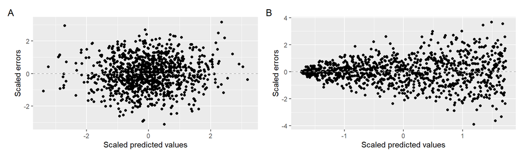

Example of A) homoscedastic data B) heteroscedastic data

## Homoscedasticity (constant variance of errors)

- The violation of this assumption has two consequences.
- Firstly, the estimation of the regression coefficients become inefficient.
- The second, more serious problem is that the estimates of the standard errors of the coefficients would be biased, leading to incorrectly specified p values and standard errors.

## Normality of errors

- Linear regression assumes that the errors are normally distributed
- Especially important for the prediction of individual observations
- Furthermore, the normality of residuals is important for the inference from small samples
  - for large enough samples, the sampling distribution of regression coefficient will approach normality no matter the distribution of residuals
- Violation of this assumptions lead to incorrect prediction for individual observations and for incorrect p values and confidence intervals in small samples ## References

Gelman, A., Hill, J., & Vehtari, A. (2020). *Regression and other stories*. Cambridge University Press. https://doi.org/10.1017/9781139161879